# Dataset and Algorithms Selection

The dataset we chose from Kaggle was "Airline Passenger Satisfaction"

https://www.kaggle.com/datasets/teejmahal20/airline-passenger-satisfaction

This dataset contains columns with numerical data for: ID, Age, Flight Distance, Departure Delay, Arrival Delay, and many more for various ratings given by passengers, such as Cleanliness and Service (from a scale of 0-5).

It also contains categorical data for: Gender, Customer Type, Type of Travel, Class, and Satisfcation.

```python
import pandas as pd
import seaborn as sns
from sklearn.svm import SVC
from sklearn.tree import DecisionTreeClassifier
from sklearn.neighbors import KNeighborsClassifier
from sklearn.preprocessing import OneHotEncoder
from sklearn.metrics import accuracy_score, confusion_matrix, f1_score


# Splitting the training and testing data
train = pd.read_csv("data/airline_train.csv")
test = pd.read_csv('data/airline_test.csv')

# Removing 300 rows of 10,000 containing null values.
train.dtypes
train = train.dropna()
train.info()

train.columns
```

```
<class 'pandas.core.frame.DataFrame'>
Index: 103594 entries, 0 to 103903
Data columns (total 25 columns):
 #   Column                             Non-Null Count   Dtype
---  ------                             --------------   -----
 0   Unnamed: 0                         103594 non-null  int64
 1   id                                 103594 non-null  int64
 2   Gender                             103594 non-null  object
 3   Customer Type                      103594 non-null  object
 4   Age                                103594 non-null  int64
 5   Type of Travel                     103594 non-null  object
 6   Class                              103594 non-null  object
 7   Flight Distance                    103594 non-null  int64
 8   Inflight wifi service              103594 non-null  int64
 9   Departure/Arrival time convenient  103594 non-null  int64
```

[output cut: 17 more lines]

```
Index(['Unnamed: 0', 'id', 'Gender', 'Customer Type', 'Age', 'Type of Travel',
       'Class', 'Flight Distance', 'Inflight wifi service',
       'Departure/Arrival time convenient', 'Ease of Online booking',
       'Gate location', 'Food and drink', 'Online boarding', 'Seat comfort',
       'Inflight entertainment', 'On-board service', 'Leg room service',
       'Baggage handling', 'Checkin service', 'Inflight service',
       'Cleanliness', 'Departure Delay in Minutes', 'Arrival Delay in Minutes',
       'satisfaction'],
      dtype='object')
```

We will be attempting to predict the satisfaction of customers based on various factors. We can create boxplots showing the Satisfaction vs some of these factors in order to get a better idea of what factors contribute most to customer satisfaction.

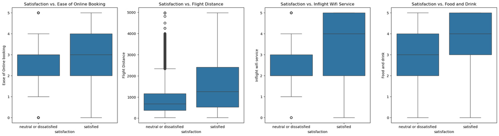

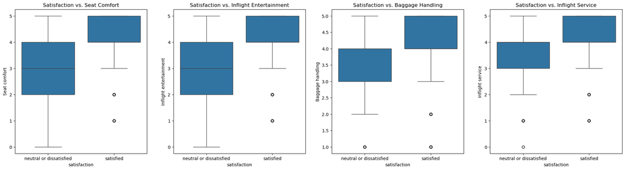

```python
import matplotlib.pyplot as plt

# Display data as boxplots.
fig,axes=plt.subplots(nrows=1,ncols=4,figsize=(25,6))
sns.boxplot(data=train,x=train["satisfaction"],y=train['Ease of Online booking'], orient="v",ax=axes[0])
axes[0].set_title("Satisfaction vs. Ease of Online Booking")

sns.boxplot(data=train,x=train["satisfaction"],y=train['Flight Distance'], orient="v",ax=axes[1])
axes[1].set_title("Satisfaction vs. Flight Distance")

sns.boxplot(data=train,x=train["satisfaction"],y=train['Inflight wifi service'], orient="v",ax=axes[2])
axes[2].set_title("Satisfaction vs. Inflight Wifi Service")

sns.boxplot(data=train,x=train["satisfaction"],y=train['Food and drink'], orient="v",ax=axes[3])
axes[3].set_title("Satisfaction vs. Food and Drink")

fig,axes=plt.subplots(nrows=1,ncols=4,figsize=(25,6))
sns.boxplot(data=train,x=train["satisfaction"],y=train['Seat comfort'], orient="v",ax=axes[0])
axes[0].set_title("Satisfaction vs. Seat Comfort")

sns.boxplot(data=train,x=train["satisfaction"],y=train['Inflight entertainment'], orient="v",ax=axes[1])
axes[1].set_title("Satisfaction vs. Inflight Entertainment")

sns.boxplot(data=train,x=train["satisfaction"],y=train['Baggage handling'], orient="v",ax=axes[2])
axes[2].set_title("Satisfaction vs. Baggage Handling")

sns.boxplot(data=train,x=train["satisfaction"],y=train['Inflight service'], orient="v",ax=axes[3])
axes[3].set_title("Satisfaction vs. Inflight Service")
```

Now we will be performing One-Hot encoding to convert the categorical data into numerical data.

```python
train = pd.get_dummies(train,columns=['Type of Travel', 'Class'], drop_first=False)
test = pd.get_dummies(test,columns=['Type of Travel', 'Class'], drop_first=False)

# Convert categorical (boolean) values into numerical (integer) values
train['Type of Travel_Business travel'] = train['Type of Travel_Business travel'].astype(int)
train['Type of Travel_Personal Travel'] = train['Type of Travel_Personal Travel'].astype(int)
train['Class_Business'] = train['Class_Business'].astype(int)
train['Class_Eco'] = train['Class_Eco'].astype(int)
train['Class_Eco Plus'] = train['Class_Eco Plus'].astype(int)

test['Type of Travel_Business travel'] = test['Type of Travel_Business travel'].astype(int)
test['Type of Travel_Personal Travel'] = test['Type of Travel_Personal Travel'].astype(int)
test['Class_Business'] = test['Class_Business'].astype(int)
test['Class_Eco'] = test['Class_Eco'].astype(int)
test['Class_Eco Plus'] = test['Class_Eco Plus'].astype(int)

test
```

|  | Unnamed: 0 | id | Gender | Customer Type | Age | Flight Distance | Inflight wifi service | Departure/Arrival time convenient | Ease of Online booking | Gate location | ... | Inflight service | Cleanliness | Departure Delay in Minutes | Arrival Delay in Minutes | satisfaction | Type of Travel_Business travel | Type of Travel_Personal Travel | Class_Business | Class_Eco | Class_Eco Plus |
| --- | --- | --- | --- | --- | --- | --- | --- | --- | --- | --- | --- | --- | --- | --- | --- | --- | --- | --- | --- | --- | --- |
| 0 | 0 | 19556 | Female | Loyal Customer | 52 | 160 | 5 | 4 | 3 | 4 | ... | 5 | 5 | 50 | 44.0 | satisfied | 1 | 0 | 0 | 1 | 0 |
| 1 | 1 | 90035 | Female | Loyal Customer | 36 | 2863 | 1 | 1 | 3 | 1 | ... | 4 | 5 | 0 | 0.0 | satisfied | 1 | 0 | 1 | 0 | 0 |
| 2 | 2 | 12360 | Male | disloyal Customer | 20 | 192 | 2 | 0 | 2 | 4 | ... | 2 | 2 | 0 | 0.0 | neutral or dissatisfied | 1 | 0 | 0 | 1 | 0 |
| 3 | 3 | 77959 | Male | Loyal Customer | 44 | 3377 | 0 | 0 | 0 | 2 | ... | 1 | 4 | 0 | 6.0 | satisfied | 1 | 0 | 1 | 0 | 0 |
| 4 | 4 | 36875 | Female | Loyal Customer | 49 | 1182 | 2 | 3 | 4 | 3 | ... | 2 | 4 | 0 | 20.0 | satisfied | 1 | 0 | 0 | 1 | 0 |
| ... | ... | ... | ... | ... | ... | ... | ... | ... | ... | ... | ... | ... | ... | ... | ... | ... | ... | ... | ... | ... | ... |
| 25971 | 25971 | 78463 | Male | disloyal Customer | 34 | 526 | 3 | 3 | 3 | 1 | ... | 5 | 4 | 0 | 0.0 | neutral or dissatisfied | 1 | 0 | 1 | 0 | 0 |
| 25972 | 25972 | 71167 | Male | Loyal Customer | 23 | 646 | 4 | 4 | 4 | 4 | ... | 5 | 4 | 0 | 0.0 | satisfied | 1 | 0 | 1 | 0 | 0 |
| 25973 | 25973 | 37675 | Female | Loyal Customer | 17 | 828 | 2 | 5 | 1 | 5 | ... | 4 | 2 | 0 | 0.0 | neutral or dissatisfied | 0 | 1 | 0 | 1 | 0 |
| 25974 | 25974 | 90086 | Male | Loyal Customer | 14 | 1127 | 3 | 3 | 3 | 3 | ... | 5 | 4 | 0 | 0.0 | satisfied | 1 | 0 | 1 | 0 | 0 |
| 25975 | 25975 | 34799 | Female | Loyal Customer | 42 | 264 | 2 | 5 | 2 | 5 | ... | 1 | 1 | 0 | 0.0 | neutral or dissatisfied | 0 | 1 | 0 | 1 | 0 |

25976 rows × 28 columns

Now we will train the model using some key predictors based on how significantly they impact customer satisfaction, such as seat comfort and inflight entertainment.

# Training and Evaluation

```python
#Training Phase
train_x = train[['Seat comfort','Inflight entertainment','Baggage handling', 'Inflight service','Ease of Online booking','Flight Distance', 'Inflight wifi service', 'Food and drink']]
train_y = train['satisfaction']
test_x = test[['Seat comfort','Inflight entertainment','Baggage handling', 'Inflight service','Ease of Online booking','Flight Distance', 'Inflight wifi service', 'Food and drink']]
test_y = test['satisfaction']
```

## Decision Tree Classifier

Decision Tree Classifier is an effective algorithm for both numerical and categorical data. It uses a tree structure where each non-leaf node represents a test on an attribute, each branch denotes an outcome of the test, and each leaf node holds a class label. Attribute values of a given sample are tested against the decision tree to predict its class. Because it can work effectively with datasets that contain both numerical and categorical data its likely to be a good choice for this dataset.

```
Accuracy: 0.8653757314444103
F1 Score: 0.843597656424706
```

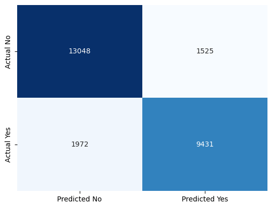

```python
from sklearn import metrics

# Create Decision Tree classifer object.
clf = DecisionTreeClassifier(max_depth=15)
model = clf.fit(train_x,train_y)

#Predict the response for test dataset.
y_pred = model.predict(test_x)

# Model Accuracy, how often is the classifier correct?
print("Accuracy:", metrics.accuracy_score(test_y, y_pred))

# Calculate the F1 score.
f1 = f1_score(test_y, y_pred, pos_label='satisfied')

# Display the F1 score.
print("F1 Score:", f1)

conf_matrix = confusion_matrix(test_y, y_pred)
sns.heatmap(conf_matrix, annot=True, fmt="d", cmap="Blues", xticklabels=['Predicted No', 'Predicted Yes'], yticklabels=['Actual No', 'Actual Yes'],cbar=False)
```

## KNN Classifier

```
Accuracy: 0.79096088697259
F1 Score: 0.7503677822728945
```

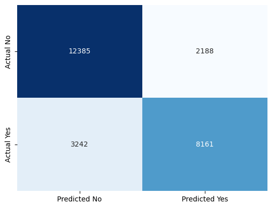

```python
# Create KNeighborsClassifier object.
# After testing several different n_neighbors, we found 3 to be the most accurate.
kn = KNeighborsClassifier(n_neighbors=3)
model=kn.fit(train_x, train_y)

# Predict the response for the dataset.
y_pred = model.predict(test_x)

# Model Accuracy, how often is the classifier correct?
print("Accuracy:", metrics.accuracy_score(test_y, y_pred))

# Calculate the F1 score
f1 = f1_score(test_y, y_pred, pos_label='satisfied')

# Display the F1 score
print("F1 Score:", f1)
conf_matrix = confusion_matrix(test_y, y_pred)
sns.heatmap(conf_matrix, annot=True, fmt="d", cmap="Blues", xticklabels=['Predicted No', 'Predicted Yes'], yticklabels=['Actual No', 'Actual Yes'],cbar=False)
```

# Analysis

Accuracy is a measure of the overall correctness of predictions made by the model, and is measured by the the ratio of correctly predicted instances to the total number of instances in the dataset.

F1 Score is the harmonic mean of both precision and recall. Precision is the ratio of retrieved relevant instances over the total number of retrieved instances. Recall is the ratio of retrieved relevant instances over the total number of relevant instances.

As shown above, Decision Tree Classifier ended up being significantly more accurate both in its Accuracy and its F1 Score.

DT Accuracy: 0.865 | KNN Accuracy: 0.791 | DT is 7.5% more accurate.

DT F1 Score: 0.844 | KNN F1 Score: 0.750 | DT has an F1 Score that was 9.4% higher.

I believe this is because Decision Tree is especially effective with simple relationships and datasets with both numerical and categorical data, whereas KNN tends to focus too much on outlier data and has difficulty deciding which features to measure distance to.